# l9_es

## Regresión bivariada: ¿Qué más?

```r
modelo_id_vox <- lm(d1$prob_vox ~ d1$ideologia)
summary(modelo_id_vox)
```

```
Call:
lm(formula = d1$prob_vox ~ d1$ideologia)

Residuals:
   Min     1Q Median     3Q    Max
-8.299 -2.364 -0.364  1.675 10.571

Coefficients:
             Estimate Std. Error t value Pr(>|t|)
(Intercept)  -1.57086    0.14342  -10.95   <2e-16 ***
d1$ideologia  0.98696    0.02585   38.19   <2e-16 ***
---
Signif. codes:  0 '***' 0.001 '**' 0.01 '*' 0.05 '.' 0.1 ' ' 1

Residual standard error: 2.859 on 1819 degrees of freedom
Multiple R-squared:  0.4449,    Adjusted R-squared:  0.4446
F-statistic:  1458 on 1 and 1819 DF,  p-value: < 2.2e-16
```

**Pregunta:** ¿Cómo sacamos el p-valor para testar nuestra hipótesis?

1. Obtenemos el t-statistic = $t = \frac{\beta-0}{se(\beta)}$
2. Observamos el valor t (considerando los grados de libertad) en nuestra querida tabla
- ¿Qué nos dice el *p-valor*?

Esta relación parece tan robusta que, considerando que esta muestra está realizada al azar, podemos extrapolar esta relación a la población.

- ¿Y el $R^2$?

```r
cor(d1$prob_vox, d1$ideologia)
```

```
[1] 0.6670438
```

## Regresión: Asunciones

La regresión es *BLUE* (Best Linear Unbiased Estimator) si:

- Validez de los datos para responder a la pregunta de investigación.
- Linealidad de la relación entre el resultado y las variables predictora [scatterplot y~x]. Ejemplo (de no): asociación entre ideología y Vox con interceptos de -1.5
- Varianza igual de errores (homocedasticidad): el modelo debe ser igual de bueno prediciendo valores altos y bajos de X. De no ser así, aumenta la p(error de tipo I)
  - Solución? Outliers? Log(Variable dependiente)?

```r
#install.packages("olsrr")
library(olsrr)

olsrr::ols_plot_resid_fit(modelo_id_vox)
```

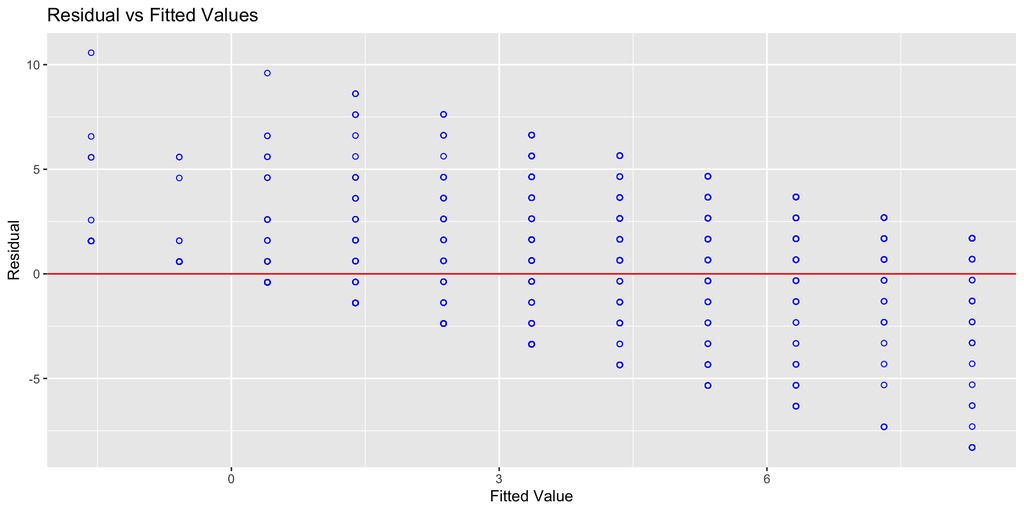

- Normalidad de errores: relacionado con la estimación de p-valores y TLC
  - $\Delta$ n, verifica la existencia de outliers, log(VD)

```r
olsrr::ols_plot_resid_hist(modelo_id_vox)
```

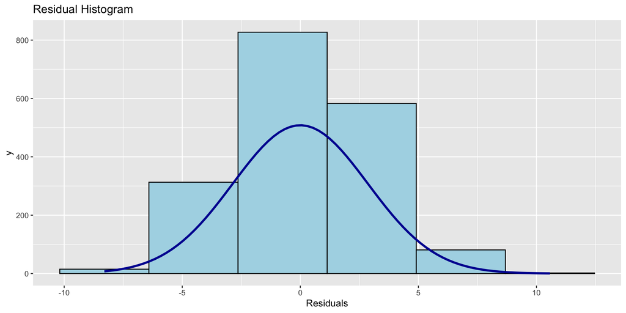

## Regresión: ¿Causalidad?

[video not shown]

## Regresión: Causalidad

¿Podemos considerar causal el efecto de la autoubicación ideológica en la p(voto a Vox)?

- Recopilemos:
  - ¿Qué nos dice la $\beta$? Cambio en Y cuando aumentamos una unidad en X.
  - ¿Qué **no*** nos dice?
    - No nos cuenta qué causa qué, sólo la asociación [*Causalidad reversa*]
    - No nos cuenta la cadena de hechos, si hay variables no-incluídas en el modelo que están causando tanto nuestra X y nuestra Y y, en realidad, son las causantes de la asociación [*Sesgo de variable omitida*]
    - Consejo: pensad en el eje de tiempo

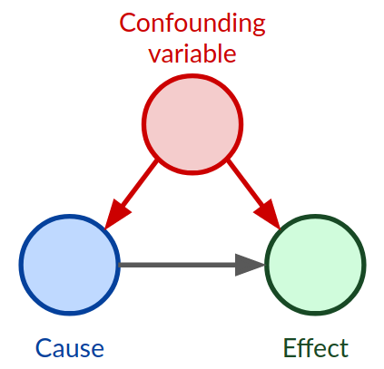

No nos explica si la ocurrencia de X conlleva un cambio en Y que no se hubiera dado en caso de contrafactuales donde dicho cambio en X no se dió. No nos habla de cuán válido o creíble es el contrafactual de X.

## Ejemplo: Los suizos

[figure not shown]

[figure not shown]

[figure not shown]

## Causalidad

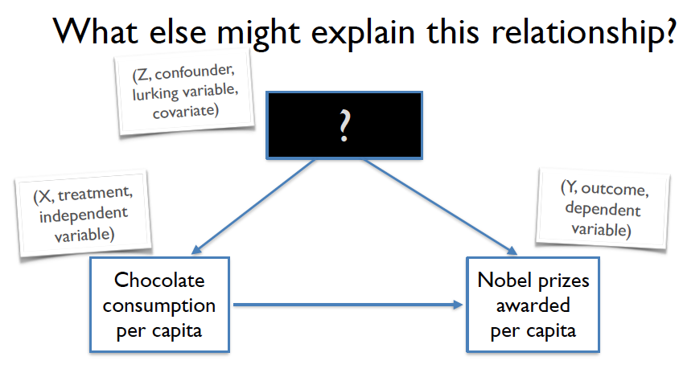

- ¿Estamos ante una relación causal o se trata de una correlación *espuria*?
- ¿Cómo encontramos *Z*s? ¿Cuáles veis aquí? Pensemos en la cadena de hechos (no sólo mecanismos, también causas que antecedan a nuestra causa)
- ¿Cómo reducimos la posibilidad de estar ante un caso de **sesgo de variable omitida**?

## Regresión: Controlar para balancear

CONTROLAR para “*BALANCEAR*” en la probabilidad de ser asignado a nuestro tratamiento

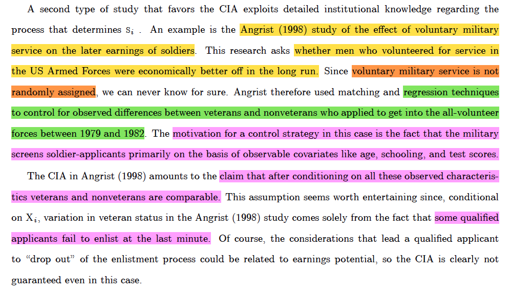

## Regresión: NO controlar por defecto

Controlar desde la teoría. Controlar por variables que *causen* nuestra X y nuestra Y; no por aquellas causadas por X

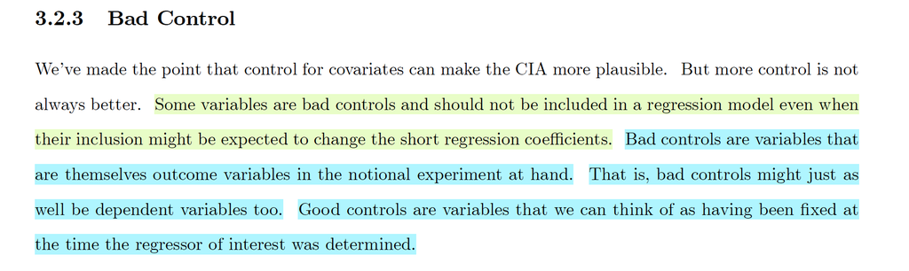

**Note**

Buena praxis es dibujar nuestro DAG [Directed Acyclic Graph]

## Regresión multivariada: Dahl controla

**Ejemplo** de un libro que habéis leído [seguramente en introducción a la ciencia política]:

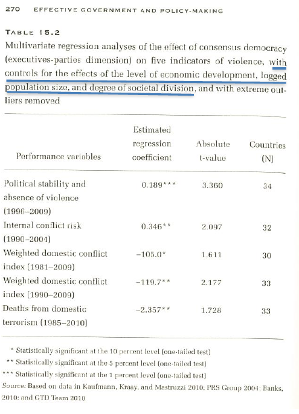

## Regresión multivariada: Cheibub controla

- **Pregunta**: ¿Tienen los sistemas presidencialistas (vs. parlamentaristas) más probabilidad de caer?
- **Teoría**: Los presidencialismos son lo peor [Linz]
- **Resultado**: Hay causas peores que anteceden nuestra “causa” (sistema presidencial)

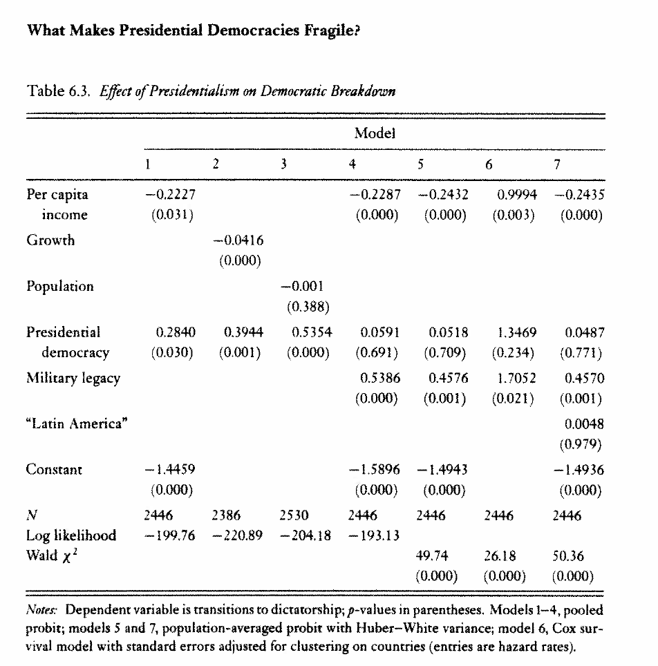

## Regresión multivariada: Fearon y Laitin

[interactive chart not shown]

[Replication data](https://dataverse.harvard.edu/dataset.xhtml?persistentId=doi:10.7910/DVN/QB3BFP)

## Regresión multivariada: Fearon y Laitin (II)

Replicamos el modelo principal de Fearon y Laitin (2003, Tabla 1) con `lm()`, es decir, un modelo de probabilidad lineal

- Variable dependiente (`onset`): **binaria**, vale 1 si empieza una guerra civil en ese país-año
- Variable independiente **continua**: `ethfrac`, fraccionalización étnica (0 = homogéneo, 1 = máxima diversidad)
- Variable independiente **binaria** (dummy): `Oil`, vale 1 si el país es exportador de petróleo

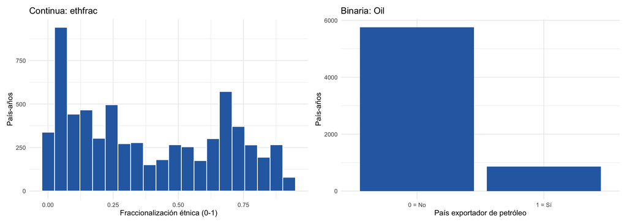

```r
library(haven)
library(tidyverse)
library(patchwork)

data_fl <- read_dta("repdata.dta") |>
  mutate(onset = ifelse(onset > 0, 1, onset))   # una observación está codificada como 4: la tratamos como 1 (así N = 6327 como en la Tabla 1)

p_cont <- ggplot(data_fl, aes(ethfrac)) +
  geom_histogram(bins = 20, fill = "#2b6cb0", color = "white") +
  labs(title = "Continua: ethfrac", x = "Fraccionalización étnica (0-1)", y = "País-años") +
  theme_minimal(base_size = 12)

p_dummy <- data_fl |>
  mutate(Oil = factor(Oil, labels = c("0 = No", "1 = Sí"))) |>
  ggplot(aes(Oil)) +
  geom_bar(fill = "#2b6cb0") +
  labs(title = "Binaria: Oil", x = "País exportador de petróleo", y = "País-años") +
  theme_minimal(base_size = 12)

p_cont | p_dummy
```

¿Cómo se relaciona cada una con la variable dependiente?

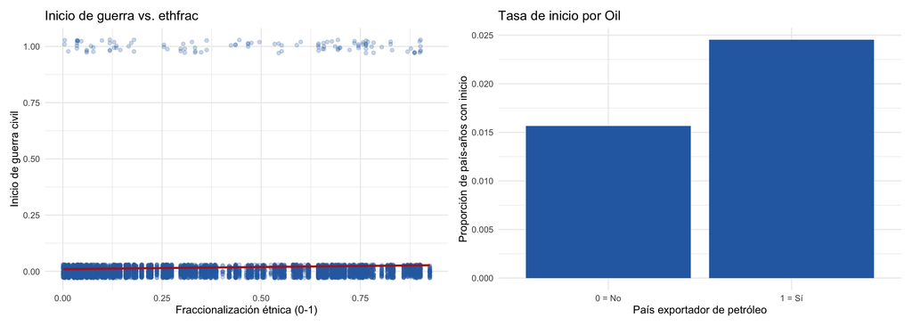

```r
p_cont2 <- ggplot(data_fl, aes(ethfrac, onset)) +
  geom_jitter(height = 0.03, alpha = 0.25, color = "#2b6cb0") +
  geom_smooth(method = "lm", se = FALSE, color = "firebrick") +
  labs(title = "Inicio de guerra vs. ethfrac", x = "Fraccionalización étnica (0-1)",
       y = "Inicio de guerra civil") +
  theme_minimal(base_size = 12)

p_dummy2 <- data_fl |>
  group_by(Oil) |>
  summarise(tasa = mean(onset, na.rm = TRUE)) |>
  mutate(Oil = factor(Oil, labels = c("0 = No", "1 = Sí"))) |>
  ggplot(aes(Oil, tasa)) +
  geom_col(fill = "#2b6cb0") +
  labs(title = "Tasa de inicio por Oil", x = "País exportador de petróleo",
       y = "Proporción de país-años con inicio") +
  theme_minimal(base_size = 12)

p_cont2 | p_dummy2
```

Con una variable dependiente binaria la nube de puntos solo tiene dos alturas (0 y 1), y la recta de `lm()` resume cómo cambia la **probabilidad** de inicio. Los exportadores de petróleo tienen una tasa de inicio más alta (alrededor del 2.5% frente al 1.6%)

## Regresión multivariada: Fearon y Laitin (III)

- Modelo 1: solo `ethfrac`
  - ¿Estamos ante una relación causal o se trata de una correlación *espuria*?
- Modelo 2: el modelo principal de la Tabla 1 (estimado con `lm()` en lugar de logit, así que los coeficientes son **cambios en la probabilidad**)

```r
library(modelsummary)

model1 <- lm(onset ~ ethfrac, data = data_fl)

model2 <- lm(onset ~ ethfrac + warl + gdpenl + lpopl1 + lmtnest + ncontig +
               Oil + nwstate + instab + polity2l + relfrac,
             data = data_fl)

cm <- c('ethfrac'     = 'Frac. étnica',
        'warl'        = 'Guerra previa',
        'gdpenl'      = 'PIB per cápita (t-1)',
        'lpopl1'      = 'Log. población',
        'lmtnest'     = 'Log. % montañoso',
        'ncontig'     = 'Estado no contiguo',
        'Oil'         = 'Petróleo',
        'nwstate'     = 'Estado nuevo',
        'instab'      = 'Inestabilidad',
        'polity2l'    = 'Polity II (t-1)',
        'relfrac'     = 'Frac. religiosa',
        '(Intercept)' = 'Intercept')

modelsummary(list("Solo ethfrac" = model1, "Modelo principal" = model2),
             coef_map = cm, stars = TRUE,
             gof_map = c("nobs", "r.squared"))
```

|  | Solo ethfrac | Modelo principal |
| --- | --- | --- |
| Frac. étnica | 0.019*** | 0.009 |
|  | (0.006) | (0.006) |
| Guerra previa |  | -0.015** |
|  |  | (0.005) |
| PIB per cápita (t-1) |  | -0.002*** |
|  |  | (0.000) |
| Log. población |  | 0.005*** |
|  |  | (0.001) |
| Log. % montañoso |  | 0.003* |
|  |  | (0.001) |
| Estado no contiguo |  | 0.008 |
|  |  | (0.005) |
| Petróleo |  | 0.016** |
|  |  | (0.005) |
| Estado nuevo |  | 0.067*** |
|  |  | (0.010) |
| Inestabilidad |  | 0.015*** |
|  |  | (0.005) |
| Polity II (t-1) |  | 0.000 |
|  |  | (0.000) |
| Frac. religiosa |  | 0.006 |
|  |  | (0.008) |
| Intercept | 0.010*** | -0.036** |
|  | (0.003) | (0.011) |
| Num.Obs. | 6610 | 6327 |
| R2 | 0.002 | 0.019 |

+ p < 0.1, * p < 0.05, ** p < 0.01, *** p < 0.001

- **Continua** (`ethfrac`): CETERIS PARIBUS, pasar de 0 a 1 (de una sociedad homogénea a la máxima diversidad) aumenta la probabilidad de inicio de guerra civil en 0.9 puntos porcentuales, manteniendo constantes los controles, aunque ya no es significativo (sin controles eran 1.9 pp)
- **Binaria** (`Oil`): CETERIS PARIBUS, pasar de 0 a 1 (ser exportador de petróleo) aumenta la probabilidad en 1.6 pp manteniendo constantes los controles (p < 0.01), y al predecir sumamos 0.016 al resto de la predicción del modelo (intercepto incluido)

## (Re-)Limitaciones: Causalidad

2 grandes limitaciones:

- Siempre habrá posibles *variables omitidas* para las que no tengamos datos (señor en la última fila)
- Las regresiones multivariables estiman efectos promedio
  - Habitualmente, nuestras teorías predicen distintas intensidades de nuestros efectos a través de otras dimensiones
  - Ejemplos de vuestros trabajos [discutir]

[figure not shown]

## Interacciones: Comparando la pendiente en distintos grupos

Hasta ahora el efecto de X sobre Y era **el mismo para todos** (una sola pendiente)

- Una interacción pregunta si ese efecto **depende** de otra variable D [moderación]
- Si tenemos dos pendientes distintas (de X a Y) para dos grupos (D) o la totalidad de los valores de una tercera variable (Z)
- Uso: cuando nuestro efecto tiene unas condiciones de alcance o un mecanismo teórico que sólo tiene un parte de nuestra población/muestra
  - Paper Xylella: El efecto de la Xylella (X) debía ocurrir en municipios con poca inversión pública (D)
  - Paper Paloterapia: El efecto de la confianza interpersonal (X) debe ocurrir en lugares con menos capacidad estatal (D)
  - Paper Gender gap en medioambiente: La brecha de género (X) se amplia según crece el PIB (D)

## Interacciones: Comparando pendientes entre grupos

**Estimación (D es una dummy)**

$$Y = \beta_0 + \beta_1 X + \beta_2 D + \beta_3 (X \times D) + \varepsilon$$

|  | Pendiente de X | Intercepto |
| --- | --- | --- |
| **D = 0** | $\beta_1$ | $\beta_0$ |
| **D = 1** | $\beta_1 + \beta_3$ | $\beta_0 + \beta_2$ |

En R, `lm(y ~ x * d)` es lo mismo que `lm(y ~ x + d + x:d)`

**Interpretación**

- $\beta_3$ es la **diferencia entre las pendientes** de los dos grupos. Si $\beta_3 = 0$, las líneas son paralelas y no hay interacción
- $\beta_1$ ya no es “el efecto de X” sino el efecto de X **cuando D = 0**. El efecto cuando D = 1 es $\beta_1 + \beta_3$, y su error estándar necesita también la covarianza entre ambos coeficientes
- $\beta_2$ es la diferencia de nivel entre grupos **cuando X = 0**

## Interacciones (continua x binaria): Bolet

[interactive chart not shown]

[Replication data](https://dataverse.harvard.edu/dataset.xhtml?persistentId=doi:10.7910/DVN/E0NUUX&widget=dataverse@harvard)

## Interacciones (continua x binaria): Extendiendo a Bolet (II)

Unidad de análisis: **distrito**. Variable dependiente: voto a UKIP en las europeas de 2014 (como en la Tabla 5 del paper). La dummy es `londres` (1 = distrito de Londres) y la variable explicativa es el cambio 2001-2011 en la proporción de trabajadores poco cualificados (`lowskill`, en pp)

```r
library(haven); library(tidyverse); library(sandwich)

census    <- read_dta("census_cps.dta") |> zap_labels() |> filter(code != "")
code_area <- read_dta("code_area.dta")  |> zap_labels() |> select(-Area)
imd       <- read_dta("imd.dta")        |> zap_labels() |> rename(code = ID_code)

d <- census |>
  left_join(code_area, by = "code") |>      # mismas uniones que Analysis.do
  left_join(imd, by = "code") |>
  mutate(londres  = rr_3,                   # dummy: 1 = Londres
         lowskill = 100 * unqualifiedsharechange,
         log_pop  = log(pop))

nrow(d)
```

```
[1] 380
```

```r
m_sin <- lm(MEP_UKIPPct ~ lowskill + londres + ResidentAge60plusshare + EU_2001Migrantshare +
              noqual_2001_sh + ManufacturingShareGrowth + umemployment_rate_aps +
              imdaveragescore + shareofstudents + log_pop, data = d)

m_int <- update(m_sin, . ~ . + lowskill:londres)   # = lowskill * londres
```

## Interacciones (continua x binaria): Extendiendo a Bolet (III)

```r
library(modelsummary)

cm <- c('lowskill'                 = 'Cambio poco cualificados',
        'londres'                  = 'Londres (1 = sí)',
        'lowskill:londres'         = 'Cambio poco cualificados × Londres',
        'ResidentAge60plusshare'   = 'Pob. 60+ (2001)',
        'EU_2001Migrantshare'      = 'Migrantes UE (2001)',
        'noqual_2001_sh'           = 'Sin cualificación (2001)',
        'ManufacturingShareGrowth' = 'Cambio empleo industrial',
        'umemployment_rate_aps'    = 'Tasa de desempleo',
        'imdaveragescore'          = 'IMD (privación)',
        'shareofstudents'          = '% estudiantes',
        'log_pop'                  = 'Log. población',
        '(Intercept)'              = 'Intercept')

modelsummary(list("Sin interacción" = m_sin, "Con interacción" = m_int),
             coef_map = cm, stars = TRUE, vcov = "HC1",
             gof_map = c("nobs", "r.squared"))
```

|  | Sin interacción | Con interacción |
| --- | --- | --- |
| Cambio poco cualificados | 0.233 | 0.519** |
|  | (0.147) | (0.158) |
| Londres (1 = sí) | -7.979*** | -1.202 |
|  | (1.678) | (2.056) |
| Cambio poco cualificados × Londres |  | -1.280*** |
|  |  | (0.264) |
| Pob. 60+ (2001) | 11.917 | 10.164 |
|  | (10.383) | (9.880) |
| Migrantes UE (2001) | 89.851* | 109.373** |
|  | (35.623) | (39.034) |
| Sin cualificación (2001) | 100.083*** | 96.551*** |
|  | (11.127) | (10.140) |
| Cambio empleo industrial | 57.162** | 42.746* |
|  | (20.027) | (20.034) |
| Tasa de desempleo | 0.091 | 0.147 |
|  | (0.145) | (0.145) |
| IMD (privación) | -0.516*** | -0.492*** |
|  | (0.082) | (0.075) |
| % estudiantes | -0.545*** | -0.593*** |
|  | (0.105) | (0.102) |
| Log. población | -0.391 | -0.265 |
|  | (0.542) | (0.531) |
| Intercept | 11.597 | 9.467 |
|  | (7.704) | (7.632) |
| Num.Obs. | 322 | 322 |
| R2 | 0.702 | 0.728 |

+ p < 0.1, * p < 0.05, ** p < 0.01, *** p < 0.001

## Interacciones (continua x binaria): Extendiendo a Bolet (IV)

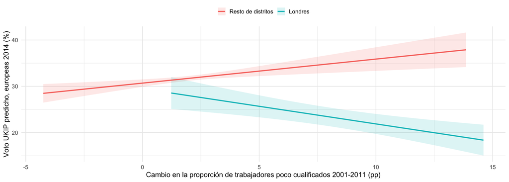

```r
b <- coef(m_int); V <- vcovHC(m_int, "HC1")

# Pendiente de lowskill fuera de Londres (b1) y en Londres (b1 + b3)
s_fuera <- b["lowskill"]
s_lon   <- b["lowskill"] + b["lowskill:londres"]
se_fuera <- sqrt(V["lowskill", "lowskill"])
se_lon   <- sqrt(V["lowskill", "lowskill"] + V["lowskill:londres", "lowskill:londres"] +
                 2 * V["lowskill", "lowskill:londres"])

fmt <- function(s, se) sprintf("%.2f pp (IC 95%%: %.2f a %.2f)", s, s - 1.96 * se, s + 1.96 * se)
txt_fuera <- fmt(s_fuera, se_fuera); txt_lon <- fmt(s_lon, se_lon)

# Predicciones con el resto de controles en su media, cada grupo en su rango observado
mf   <- model.frame(m_int)
base <- mf |> select(-MEP_UKIPPct, -lowskill, -londres) |> summarise(across(everything(), mean))
rng  <- mf |> group_by(londres) |> summarise(lo = min(lowskill), hi = max(lowskill))

grid <- rng |> rowwise() |>
  reframe(londres = londres, lowskill = seq(lo, hi, length.out = 50)) |>
  bind_cols(base)

X <- model.matrix(delete.response(terms(m_int)), grid)[, names(b)]
grid$fit <- drop(X %*% b)
grid$se  <- sqrt(rowSums((X %*% V) * X))

grid |>
  mutate(grupo = factor(londres, levels = c(0, 1), labels = c("Resto de distritos", "Londres"))) |>
  ggplot(aes(lowskill, fit, color = grupo, fill = grupo)) +
  geom_ribbon(aes(ymin = fit - 1.96 * se, ymax = fit + 1.96 * se), alpha = 0.15, color = NA) +
  geom_line(linewidth = 1.1) +
  labs(x = "Cambio en la proporción de trabajadores poco cualificados 2001-2011 (pp)",
       y = "Voto UKIP predicho, europeas 2014 (%)", color = NULL, fill = NULL) +
  theme_minimal(base_size = 14) +
  theme(legend.position = "top")
```

- **Fuera de Londres** ($\beta_1$): cada punto más de trabajadores poco cualificados se asocia con 0.52 pp (IC 95%: 0.21 a 0.83)
- **En Londres** ($\beta_1 + \beta_3$): -0.76 pp (IC 95%: -1.17 a -0.35)
- **Interacción** ($\beta_3$): la pendiente en Londres es -1.28 pp menor que en el resto, y la diferencia es significativa
- Las dos rectas parten de niveles parecidos, pero se abren en sentidos contrarios. Fuera de Londres el voto a UKIP crece con el cambio en la composición laboral y en Londres cae

[figure not shown]

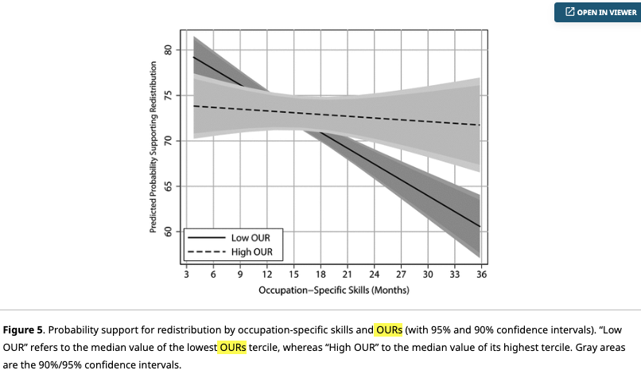

## Interacciones: Resumiendo la diferencia de la pendiente a través de otra variable

Si el moderador Z es continuo no hay “dos pendientes” sino **una pendiente distinta para cada valor de Z**

$$Y = \beta_0 + \beta_1 X + \beta_2 Z + \beta_3 (X \times Z) + \varepsilon \qquad\Rightarrow\qquad \dfrac{\partial Y}{\partial X} = \beta_1 + \beta_3 Z$$

**Estimación**

- En R, `lm(y ~ x * z)` es lo mismo que `lm(y ~ x + z + x:z)`
- El efecto de X se calcula **en valores concretos de Z** (mínimo, media, máximo, o ±1 SD de Z)

**Interpretación**

- $\beta_3$ es cuánto cambia el efecto de X por cada **unidad más de Z**. Su signo dice si el efecto crece o decrece con Z
- $\beta_1$ es el efecto de X **cuando Z = 0**. Solo tiene sentido si Z = 0 es un valor real de la variable (si no, conviene centrar Z)
- $\beta_2$ es el efecto de Z cuando X = 0
- Ningún coeficiente por separado cuenta la historia completa: hay que leer el efecto de X en distintos valores de Z

## Interacciones (continua x continua): Extendiendo a Fearon y Laitin

**Pregunta**: ¿Y si el efecto de fraccionalización étnica fuera distinto en autocracias y democracias?

```r
library(modelsummary)

m_sin <- lm(onset ~ ethfrac + polity2l + warl + gdpenl + lpopl1 + lmtnest +
              ncontig + Oil + nwstate + instab + relfrac, data = data_fl)

m_int <- update(m_sin, . ~ . + ethfrac:polity2l)    # = ethfrac * polity2l

cm <- c('ethfrac'          = 'Frac. étnica',
        'polity2l'         = 'Polity II (t-1)',
        'ethfrac:polity2l' = 'Frac. étnica × Polity II',
        'warl'             = 'Guerra previa',
        'gdpenl'           = 'PIB per cápita (t-1)',
        'lpopl1'           = 'Log. población',
        'lmtnest'          = 'Log. % montañoso',
        'ncontig'          = 'Estado no contiguo',
        'Oil'              = 'Petróleo',
        'nwstate'          = 'Estado nuevo',
        'instab'           = 'Inestabilidad',
        'relfrac'          = 'Frac. religiosa',
        '(Intercept)'      = 'Intercept')

modelsummary(list("Sin interacción" = m_sin, "Con interacción" = m_int),
             coef_map = cm, stars = TRUE,
             gof_map = c("nobs", "r.squared"))
```

|  | Sin interacción | Con interacción |
| --- | --- | --- |
| Frac. étnica | 0.009 | 0.012+ |
|  | (0.006) | (0.006) |
| Polity II (t-1) | 0.000 | -0.000 |
|  | (0.000) | (0.000) |
| Frac. étnica × Polity II |  | 0.001+ |
|  |  | (0.001) |
| Guerra previa | -0.015** | -0.015** |
|  | (0.005) | (0.005) |
| PIB per cápita (t-1) | -0.002*** | -0.002*** |
|  | (0.000) | (0.000) |
| Log. población | 0.005*** | 0.005*** |
|  | (0.001) | (0.001) |
| Log. % montañoso | 0.003* | 0.003* |
|  | (0.001) | (0.001) |
| Estado no contiguo | 0.008 | 0.008+ |
|  | (0.005) | (0.005) |
| Petróleo | 0.016** | 0.015** |
|  | (0.005) | (0.005) |
| Estado nuevo | 0.067*** | 0.067*** |
|  | (0.010) | (0.010) |
| Inestabilidad | 0.015*** | 0.015** |
|  | (0.005) | (0.005) |
| Frac. religiosa | 0.006 | 0.005 |
|  | (0.008) | (0.008) |
| Intercept | -0.036** | -0.035** |
|  | (0.011) | (0.011) |
| Num.Obs. | 6327 | 6327 |
| R2 | 0.019 | 0.019 |

+ p < 0.1, * p < 0.05, ** p < 0.01, *** p < 0.001

```r
# Efecto de ethfrac (de 0 a 1) en distintos valores de polity2l, en puntos porcentuales
b <- coef(m_int); V <- vcov(m_int)

efecto <- function(z) {
  s  <- b["ethfrac"] + b["ethfrac:polity2l"] * z
  se <- sqrt(V["ethfrac", "ethfrac"] + z^2 * V["ethfrac:polity2l", "ethfrac:polity2l"] +
             2 * z * V["ethfrac", "ethfrac:polity2l"])
  sprintf("%.1f pp (IC 95%%: %.1f a %.1f)", 100 * s, 100 * (s - 1.96 * se), 100 * (s + 1.96 * se))
}

txt_aut <- efecto(-10); txt_med <- efecto(0); txt_dem <- efecto(10)
```

- **Interacción** ($\beta_3$): cada punto más de Polity II aumenta en 0.15 pp el efecto de pasar de `ethfrac` 0 a 1, aunque solo es significativo al 10%
- **Autocracia plena** (`polity2l` = -10): -0.3 pp (IC 95%: -2.1 a 1.5)
- **Punto medio** (`polity2l` = 0), que es el coeficiente de `ethfrac` ($\beta_1$): 1.2 pp (IC 95%: -0.1 a 2.4)
- **Democracia plena** (`polity2l` = 10): 2.6 pp (IC 95%: 0.4 a 4.8)
- La diversidad étnica se asocia con más riesgo de guerra civil solo en regímenes democráticos; en autocracias el efecto no se distingue de cero

## Interacciones: Usos y limitaciones

Oportunidades para:

- Contrastar hipótesis condicionales (“X afecta a Y solo cuando Z…”) en lugar de efectos medios
- Distinguir mecanismos y contextos que explican por qué un mismo efecto cambia entre grupos
- Evitar conclusiones engañosas cuando el efecto promedio esconde efectos opuestos para distintos grupos

Limitaciones de:

- Los coeficientes por separado no se pueden leer solos: $\beta_1$ es el efecto cuando Z = 0, que puede no existir en los datos
- Menos potencia (menos obs), porque se necesita mucha muestra para detectar diferencias entre efectos
- Soporte común: sin observaciones de X en todos los valores de Z, se extrapola sin mucho sentido
- Interactuar dos variables endógenas (no-exógenas) no genera aleatoriedad
- El moderador no suele ser aleatorio, y la interacción no es causal aunque X lo sea

[figure not shown]

## ¡Nos vemos el próximo martes! Cualquier duda a smsoler@clio.uc3m.es

Seminario de Investigación